# How do we best predict the total confirmed COVID-19 cases count?

## Introduction

We would like to explore which variables can best predict the total confirmed COVID-19 count of a region. This dataset includes quantitative and qualitative data about the COVID-19 pandemic. The data gathered at https://github.com/open-covid-19/data is collected from many different sources, including the University of Oxford, the NOAA, the WorldBank Database, WorldPop, DataCommons, and many more. The full list can be found in the README file. Some variables of interest include `cancel_public_events`, `school_closing`, and `mobility_transit_stations` This is interesting to us because we would like to discover exactly what predictors can be predict the total confirmed COVID-19 count of a region to see what really affects the impact of the virus, and we personally believe that variables such as population density, restrictions on gatherings, population age, cormorbidity mortality rate, and general mobility affect the impact of COVID-19 on a region the most. The goal of the model is to see which variables truly affect the COVID-19 count of a region.

## Methods

### Data Preparation

```r
# github repo: https://github.com/open-covid-19/data
# loading this data takes awhile, storing as .csv might be faster although out of date
# data_full <- read_csv("https://storage.googleapis.com/covid19-open-data/v2/main.csv")
# write_csv(data_full, "data_full.csv")
data_full <- read_csv("data_full.csv", guess_max = 3825711)
```

Figuring out which columns have a lot of NAs and avoiding them - although issue might be in certain countries and earlier dates (before the pandemic started)

Take complete cases so linear regression doesn’t fail. Use only certain columns we need for checking

```r
# include country to be able to filter by US
# subregion2_code = FIPS (zip) code
must_include = c("total_confirmed", "country_code")

possible = c("population", "urban_population", "population_density", "human_development_index", "gdp_per_capita", "date", "life_expectancy", "comorbidity_mortality_rate", "physicians", "school_closing", "cancel_public_events", "restrictions_on_gatherings", "stay_at_home_requirements", "mobility_retail_and_recreation", "mobility_parks", "mobility_transit_stations", "mobility_workplaces", "mobility_residential")

possible_list <- data.frame()
for (i in 1:length(possible)) {
  current = c(must_include, possible[i])
  complete_vec = complete.cases(data_full[, current])
  clean_data = data_full[complete_vec, ]
  good = nrow(clean_data) > 1
  add = 1
  while (good && i + add < length(possible)) {
    possible_list = rbind(possible_list, data.frame(columns = str_c(current, collapse = ","), rows = nrow(clean_data), cols = length(current)))
    current = c(current, possible[i + add])
    complete_vec = complete.cases(data_full[, current])
    clean_data = data_full[complete_vec, ]
    good = nrow(clean_data) > 1
    add = add + 1
  }
}

max_cols = possible_list[which.max(possible_list$cols),]
columns_kept = str_split(max_cols$columns, ",")[[1]]
(rows_excluded = possible[!(possible %in% columns_kept)])
```

```
## [1] "mobility_workplaces"  "mobility_residential"
```

```r
max_cols$rows
```

```
## [1] 16800
```

```r
complete_vec = complete.cases(data_full[, columns_kept])
clean_data = data_full[complete_vec, columns_kept]
```

Normalizing the population counts because absolute numbers probably don’t add any predictive power

```r
population_data = subset(clean_data, select = grepl("population_age_", names(clean_data)))
total_populations = apply(population_data, MARGIN = 1, FUN = sum)
normalized_population = data.frame(t(t(population_data) / total_populations))
```

Setting the `date` column as a Date object, rather than a factor variable

```r
clean_data$date <- as.Date(clean_data$date)
```

Select columns that would best fit our goal

```r
clean_data_subset = clean_data %>%
  bind_cols(normalized_population) %>%
  filter(country_code == "US") %>%
  subset(select = -country_code)
```

Then, remove some variables who had VIFs as large as the thousands and tens of thousands, which would negatively impact the overall model.

```r
# saving the cleaned dataset so that we don't have to keep running above code
write_csv(clean_data_subset, "clean_data_subset.csv")
clean_data_subset = read.csv("clean_data_subset.csv")
clean_data_subset = clean_data_subset %>% subset(select = c(total_confirmed, school_closing, cancel_public_events, stay_at_home_requirements, mobility_parks, mobility_transit_stations))
names(clean_data_subset)
```

```
## [1] "total_confirmed"           "school_closing"
## [3] "cancel_public_events"      "stay_at_home_requirements"
## [5] "mobility_parks"            "mobility_transit_stations"
```

Above are the variables that seem to initially have a strong connection to the response, `total_confirmed`.

```r
clean_data_subset$date = NULL
```

### Scatter Plot Matrix

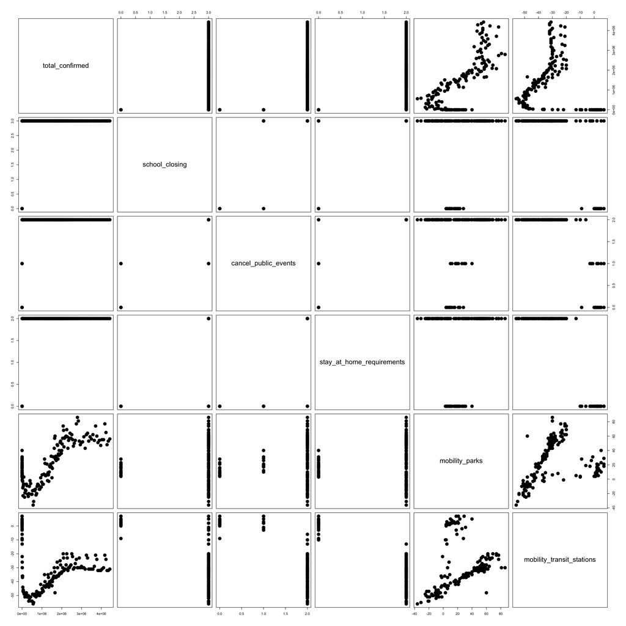

```r
pairs(clean_data_subset, pch = 20, cex = 3)
```

```r
cor(clean_data_subset)
```

```
##                           total_confirmed school_closing cancel_public_events
## total_confirmed                 1.0000000      0.3991407            0.4527863
## school_closing                  0.3991407      1.0000000            0.9157548
## cancel_public_events            0.4527863      0.9157548            1.0000000
## stay_at_home_requirements       0.5106582      0.7814108            0.8864964
## mobility_parks                  0.7787016      0.1219561            0.1138496
## mobility_transit_stations      -0.1288902     -0.6898667           -0.7761716
##                           stay_at_home_requirements mobility_parks
## total_confirmed                           0.5106582      0.7787016
## school_closing                            0.7814108      0.1219561
## cancel_public_events                      0.8864964      0.1138496
## stay_at_home_requirements                 1.0000000      0.1192097
## mobility_parks                            0.1192097      1.0000000
## mobility_transit_stations                -0.8459769      0.3421679
##                           mobility_transit_stations
## total_confirmed                          -0.1288902
## school_closing                           -0.6898667
## cancel_public_events                     -0.7761716
## stay_at_home_requirements                -0.8459769
## mobility_parks                            0.3421679
## mobility_transit_stations                 1.0000000
```

- `school_closing` and `cancel_public_events` and `stay_at_home_requiremenets` have collinearity.
- `cancel_public_events` and `stay_at_home_requirements` have collinearity.

Perform backwards and forward AIC and BIC on the full additive model, and then use anova() to pick the best model out of the 4.

```r
# additive
full_add_model = lm(total_confirmed ~ ., data = clean_data_subset)
```

```r
# back aic
back_aic = step(full_add_model, direction = "backward", trace = 0)
# back bic
n = length(full_add_model$residuals)
back_bic = step(full_add_model, direction = "backward", k = log(n), trace = 0)
# forward aic
null_model = lm(total_confirmed ~ 1, data = clean_data_subset)
forward_aic = step(
  null_model,
  scope = total_confirmed ~ school_closing + cancel_public_events + stay_at_home_requirements + mobility_parks + mobility_transit_stations,
  direction = "forward", trace = 0)
# forward bic
forward_bic = step(
  null_model,
  scope = total_confirmed ~ school_closing + cancel_public_events + stay_at_home_requirements + mobility_parks + mobility_transit_stations,
  direction = "forward", k = log(n), trace = 0)
```

```r
# use anova to compare to models created from AIC and BIC
(back_aic_pvalue = anova(back_aic, full_add_model)[2, "Pr(>F)"])
```

```
## [1] 0.352139
```

```r
(back_bic_pvalue = anova(back_bic, full_add_model)[2, "Pr(>F)"])
```

```
## [1] 0.1430077
```

```r
(forward_aic_pvalue = anova(forward_aic, full_add_model)[2, "Pr(>F)"])
```

```
## [1] 0.352139
```

```r
(forward_bic_pvalue = anova(forward_bic, full_add_model)[2, "Pr(>F)"])
```

```
## [1] 0.1430077
```

```r
back_aic$coef
```

```
##               (Intercept) stay_at_home_requirements            mobility_parks
##                -559725.04                 363245.53                  36301.58
## mobility_transit_stations
##                 -16914.93
```

```r
forward_aic$coef
```

```
##               (Intercept)            mobility_parks stay_at_home_requirements
##                -559725.04                  36301.58                 363245.53
## mobility_transit_stations
##                 -16914.93
```

The coefficients of these two models are the same, so we can use either.

```r
step_from_add = back_aic
```

```r
vif(step_from_add)
```

```
## stay_at_home_requirements            mobility_parks mobility_transit_stations
##                 10.508598                  3.384036                 11.732940
```

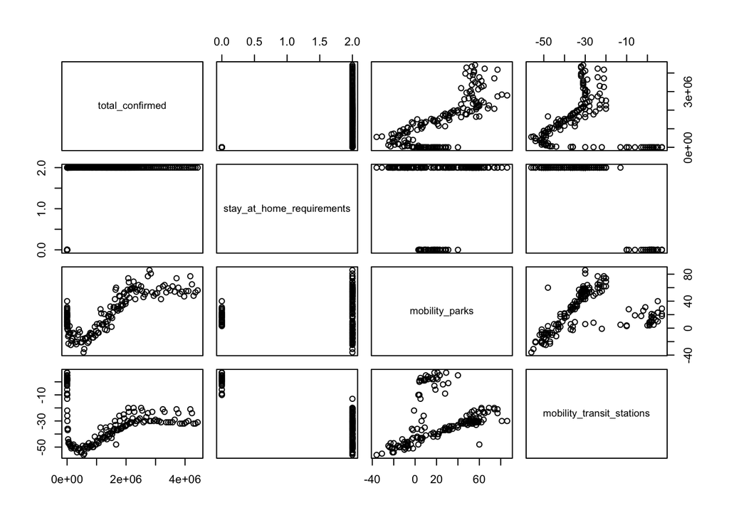

```r
plot(step_from_add$model)
```

The vifs are not terrible on this model, however, based on these plots, it is possible to do better.

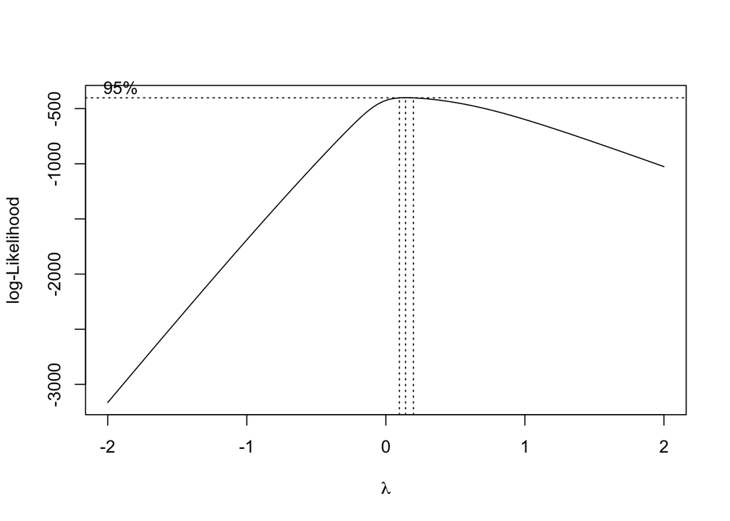

```r
#boxcox model
library(MASS)
library(faraway)
boxcox(step_from_add, plotit = TRUE)
```

```r
log_step_from_add = lm(log(total_confirmed) ~ stay_at_home_requirements + mobility_parks + mobility_transit_stations, data = clean_data_subset)
```

Perform backwards and forward AIC and BIC on the interactive model that goes up to 2-way interactions, and then use anova() to pick the best model out of the 4.

```r
# interaction
int_model = lm(total_confirmed ~ (school_closing + cancel_public_events + stay_at_home_requirements + mobility_parks + mobility_transit_stations)^2, data = clean_data_subset)
```

Using our model that includes all the interactions, we can use those as starting points for the AIC and BIC created models.

```r
# back aic
back_aic = step(int_model, direction = "backward", trace = 0)
# back bic
n = length(int_model$residuals)
back_bic = step(int_model, direction = "backward", k = log(n), trace = 0)
# forward aic
null_model = lm(total_confirmed ~ 1, data = clean_data_subset)
forward_aic = step(
  null_model,
  scope = total_confirmed ~ (school_closing + cancel_public_events + stay_at_home_requirements + mobility_parks + mobility_transit_stations)^2,
  direction = "forward", trace = 0)
# forward bic
forward_bic = step(
  null_model,
  scope = total_confirmed ~ (school_closing + cancel_public_events + stay_at_home_requirements + mobility_parks + mobility_transit_stations)^2,
  direction = "forward", k = log(n), trace = 0)
```

```r
# use anova to compare to models created from AIC and BIC
(back_aic_pvalue = anova(back_aic, int_model)[2, "Pr(>F)"])
```

```
## [1] 0.999351
```

```r
(back_bic_pvalue = anova(back_bic, int_model)[2, "Pr(>F)"])
```

```
## [1] 0.5093113
```

```r
(forward_aic_pvalue = anova(forward_aic, int_model)[2, "Pr(>F)"])
```

```
## [1] 0.999351
```

```r
(forward_bic_pvalue = anova(forward_bic, int_model)[2, "Pr(>F)"])
```

```
## [1] 0.5093113
```

- The model created from backwards AIC predicts better than the interaction model with a p-value of 0.999351.
- The model created from backwards BIC predicts better than the interaction model with a p-value of 0.5093113.
- The model created from forwards AIC predicts better than the interaction model with a p-value of 0.999351.
- The model created from forwards BIC predicts better than the interaction model with a p-value of 0.5093113.

From the above p-values, it seems that the model created from backwards AIC and the model created from forwards AIC are the best, so we will compare those.

```r
back_aic$coef
```

```
##                              (Intercept)
##                              -16292.3732
##                stay_at_home_requirements
##                             -115976.7245
##                           mobility_parks
##                                2017.8962
##                mobility_transit_stations
##                              -24936.2079
## stay_at_home_requirements:mobility_parks
##                               24425.4783
## mobility_parks:mobility_transit_stations
##                                 371.4542
```

```r
forward_aic$coef
```

```
##                              (Intercept)
##                              -16292.3732
##                           mobility_parks
##                                2017.8962
##                stay_at_home_requirements
##                             -115976.7245
##                mobility_transit_stations
##                              -24936.2079
## mobility_parks:stay_at_home_requirements
##                               24425.4783
## mobility_parks:mobility_transit_stations
##                                 371.4542
```

Since they have the same coefficients, these 2 models are the same.

```r
step_from_int = back_aic
vif(step_from_int)
```

```
##                stay_at_home_requirements
##                                 15.65446
##                           mobility_parks
##                                 56.36842
##                mobility_transit_stations
##                                 12.79311
## stay_at_home_requirements:mobility_parks
##                                 83.37662
## mobility_parks:mobility_transit_stations
##                                 17.19622
```

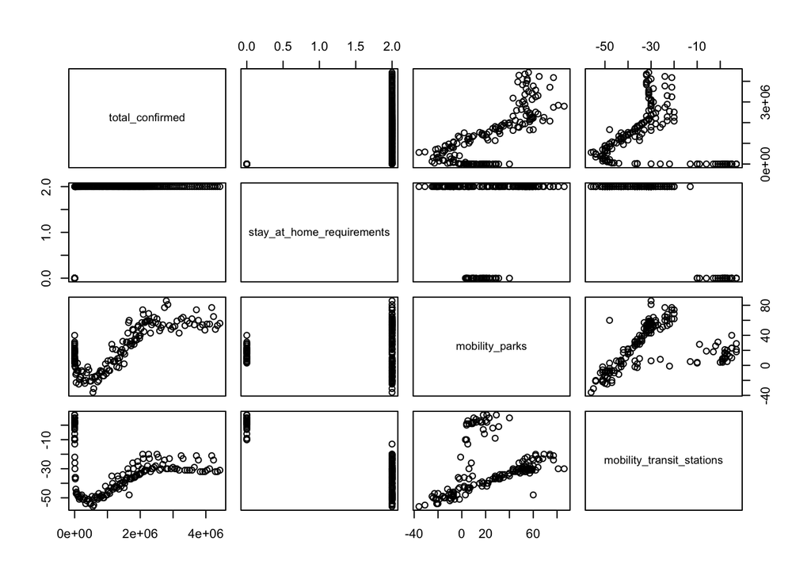

```r
plot(step_from_int$model)
```

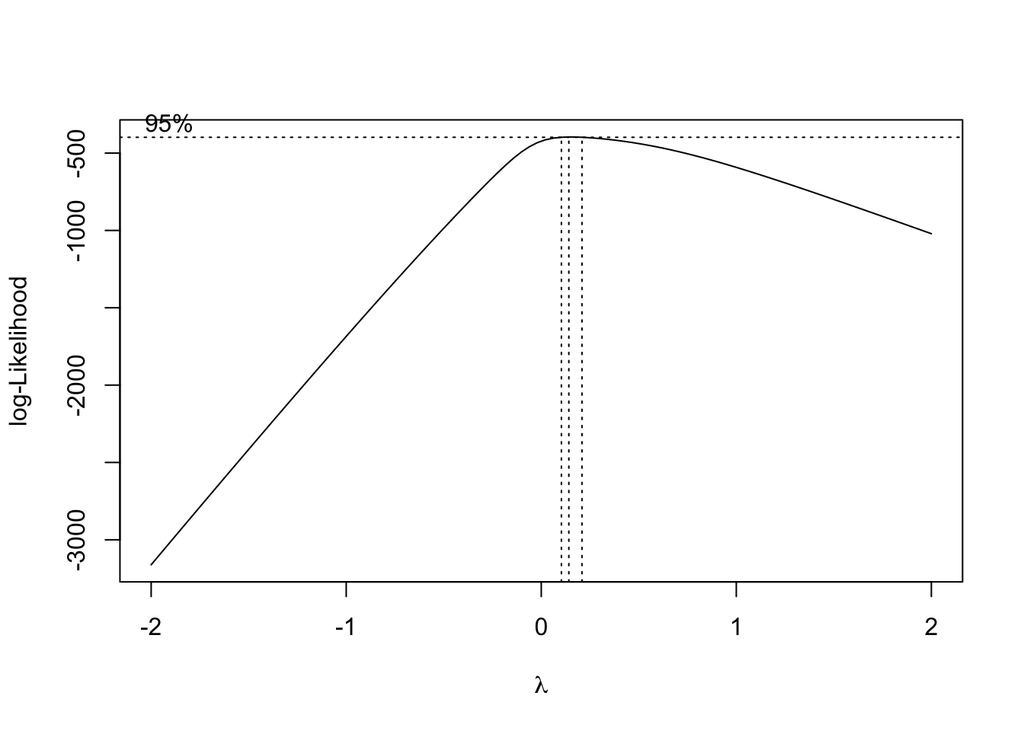

```r
#boxcox model
library(MASS)
library(faraway)
boxcox(step_from_int, plotit = TRUE)
```

```r
log_step_from_int = lm(log(total_confirmed) ~ stay_at_home_requirements + mobility_parks + mobility_transit_stations + stay_at_home_requirements:mobility_parks + mobility_parks:mobility_transit_stations, data = clean_data_subset)
```

### Check Assumptions

```r
fitted_vs_residuals = function(model) {
  plot(model$fitted.values, model$residuals, pch = 20,
       xlab = "Fitted", ylab = "Residuals", main = "Fitted vs. Residuals")
  abline(h = 0, lwd = 2, col = "red")
}

library(lmtest)
get_bp_pvalue = function(model) {
  as.vector(bptest(model)$p.value)
}

residual_histogram = function(model) {
  hist(model$residuals,
       xlab = "Residuals", main = "Histogram of Residuals", breaks = 50)
}

qq_plot = function(model) {
  qqnorm(model$residuals, main = "Normal Q-Q Plot", pch = 20)
  qqline(model$residuals, lwd = 2, col = "red")
}

get_shapiro_pvalue = function(model) {
  shapiro.test(model$residuals)$p.value
}
```

## Check assumptions for the best model of the 4 models created from using step on the simple additive model with a logged response.

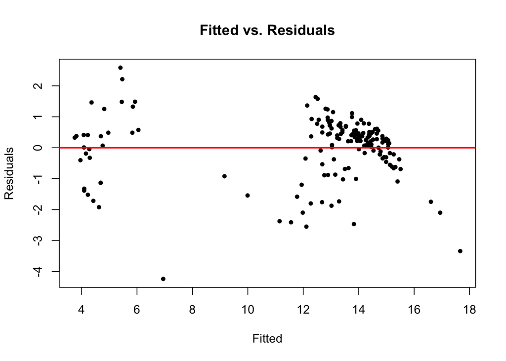

```r
# Linearity and Constant Variance Assumption
fitted_vs_residuals(log_step_from_add)
```

```r
(bp_pvalue = get_bp_pvalue(log_step_from_add))
```

```
## [1] 0.003553111
```

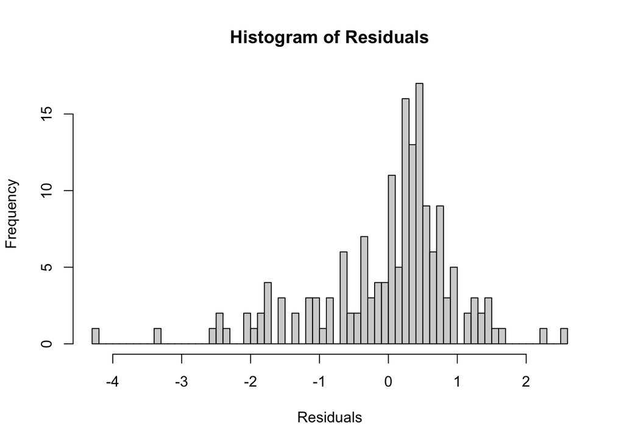

```r
# Normality Assumption
residual_histogram(log_step_from_add)
```

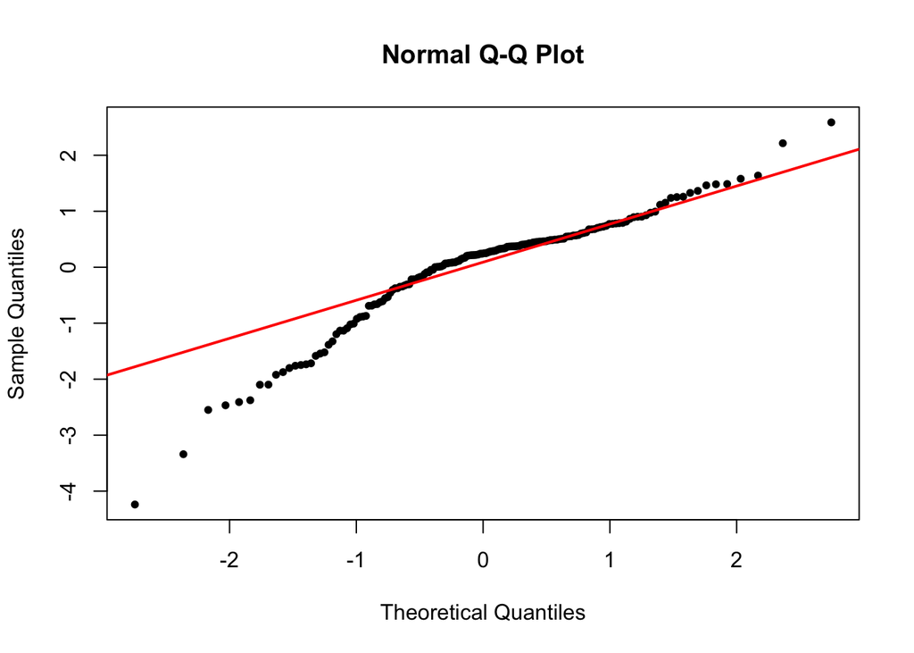

```r
qq_plot(log_step_from_add)
```

```r
(shapiro_pvalue = get_shapiro_pvalue(log_step_from_add))
```

```
## [1] 5.313572e-08
```

#### Linearity assumption

From the Fitted vs. Residuals plot, I think the mean of the residuals is *roughly* 0, so the linearity assumption can be argued to be followed.

#### Constant Variance Assumption

From the Fitted vs. Residuals plot, the spread of the residuals is not very similar for each fitted value. In addition, the p-value of the Breusch-Pagan test is 0.0035531, which is not great. Therefore, the constant variance assumption has been violated.

#### Normality Assumption

From the Normal Q-Q Plot, the datapoints follow the qqline relatively well. The Histogram of Residuals looks a little bit like the normal curve. However, the p-value of the Shapiro-Wilkes test if 5.313571610^{-8}, which is too small. Therefore, the normality assumption has been violated.

#### Check model statistics for the best model of the 4 models created from using step on the simple additive model with a logged response.

- LOOCV

```r
calc_loocv_rmse = function(model) {
  sqrt(mean((resid(model) / (1 - hatvalues(model))) ^ 2))
}

calc_loocv_rmse(log_step_from_add)
```

```
## [1] 1.053327
```

- R^2

```r
summary(log_step_from_add)$r.squared
```

```
## [1] 0.928071
```

```r
summary(log_step_from_add)$adj.r.squared
```

```
## [1] 0.926739
```

## Check assumptions for the best model of the 4 models created from using step on the interactive model with a logged response.

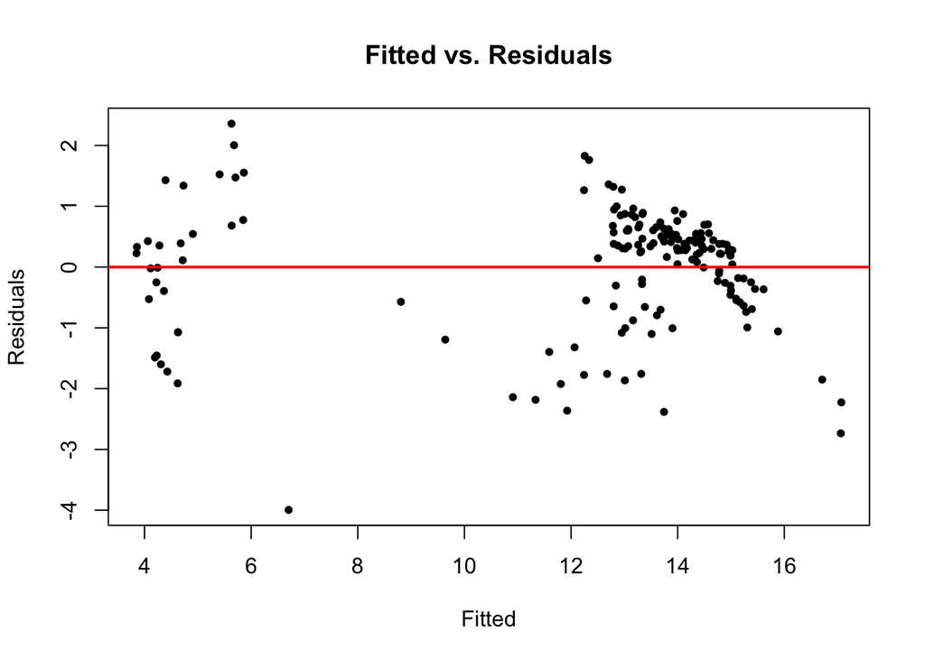

```r
# Linearity and Constant Variance Assumption
fitted_vs_residuals(log_step_from_int)
```

```r
(bp_pvalue = get_bp_pvalue(log_step_from_int))
```

```
## [1] 0.0001923814
```

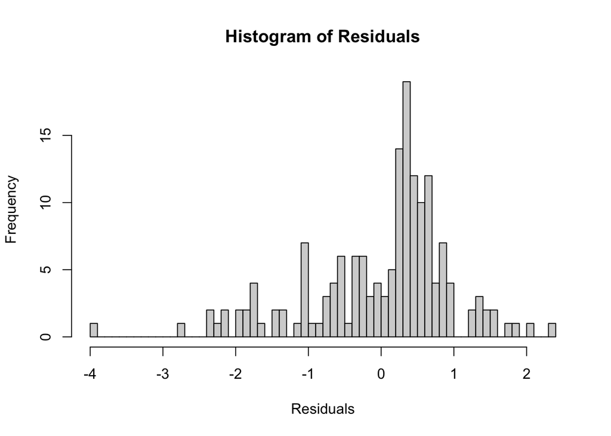

```r
# Normality Assumption
residual_histogram(log_step_from_int)
```

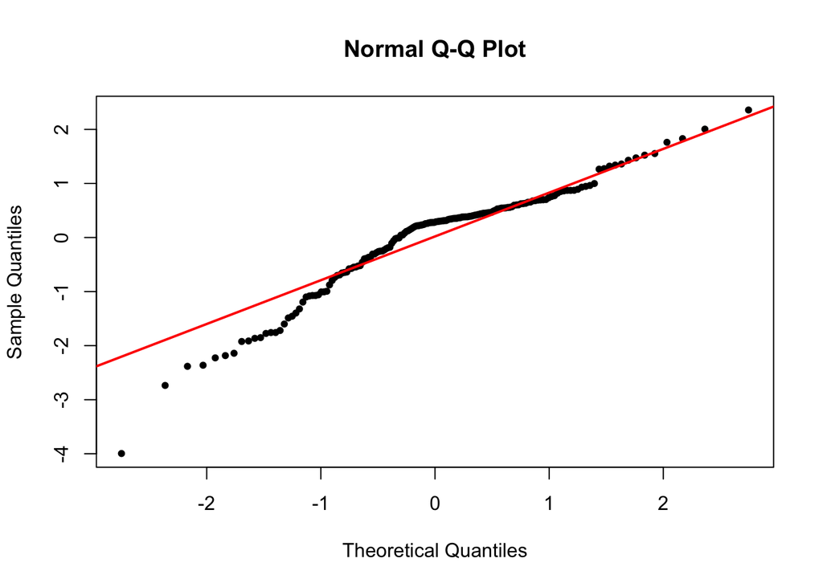

```r
qq_plot(log_step_from_int)
```

```r
(shapiro_pvalue = get_shapiro_pvalue(log_step_from_int))
```

```
## [1] 9.128324e-07
```

#### Linearity assumption

From the Fitted vs. Residuals plot, I think the mean of the residuals is *roughly* 0, so the linearity assumption can be argued to be followed.

#### Constant Variance Assumption

From the Fitted vs. Residuals plot, the spread of the residuals is not very similar for each fitted value. In addition, the p-value of the Breusch-Pagan test is 1.923813510^{-4}, which is not great. Therefore, the constant variance assumption has been violated.

#### Normality Assumption

From the Normal Q-Q Plot, the datapoints follow the qqline relatively well. The Histogram of Residuals looks a little bit like the normal curve. However, the p-value of the Shapiro-Wilkes test if 9.128323610^{-7}, which is too small. Therefore, the normality assumption has been violated.

#### Check model statistics for the best model of the 4 models created from using step on the interactive model with a logged response.

- LOOCV

```r
calc_loocv_rmse(log_step_from_int)
```

```
## [1] 1.057233
```

- R^2

```r
summary(log_step_from_int)$r.squared
```

```
## [1] 0.930412
```

```r
summary(log_step_from_int)$adj.r.squared
```

```
## [1] 0.9282374
```

To improve the best model of the 4 models created from using step on the simple additive model with a logged response, try some transformations on the predictors.

```r
log_step_from_add$coef
```

```
##               (Intercept) stay_at_home_requirements            mobility_parks
##                3.82709596                1.60458992                0.06729158
## mobility_transit_stations
##               -0.13730241
```

```r
transformed_log_step_from_add = lm(log(total_confirmed) ~ stay_at_home_requirements + I(stay_at_home_requirements^2) + mobility_parks + mobility_transit_stations, data = clean_data_subset)
```

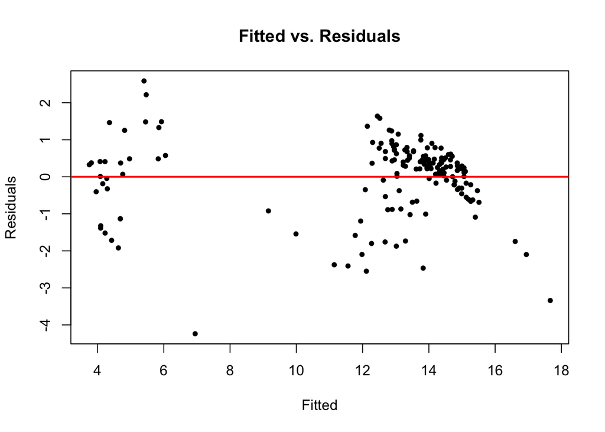

```r
# Linearity and Constant Variance Assumption
fitted_vs_residuals(transformed_log_step_from_add)
```

```r
(bp_pvalue = get_bp_pvalue(transformed_log_step_from_add))
```

```
## [1] 0.003553111
```

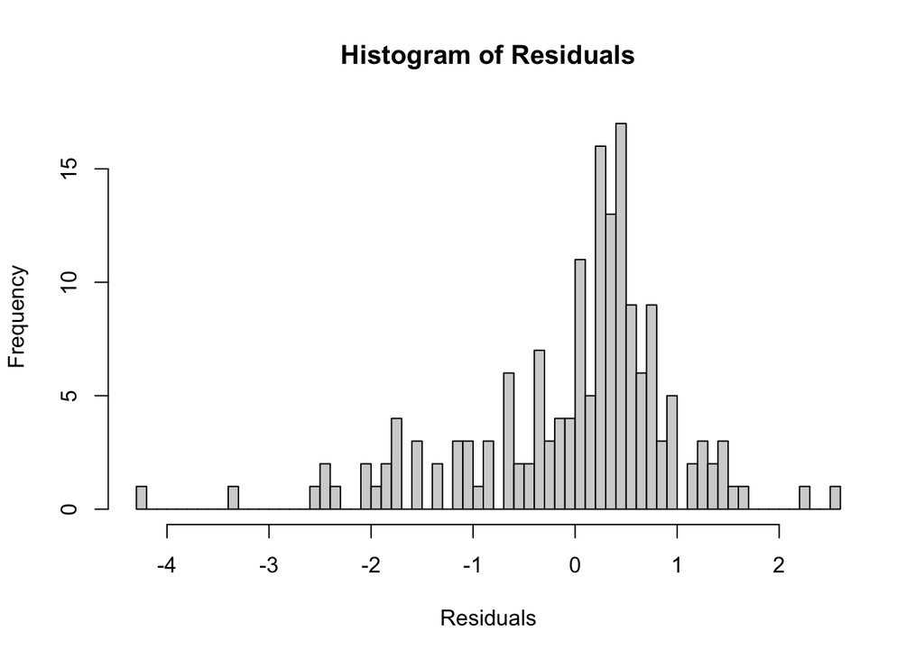

```r
# Normality Assumption
residual_histogram(transformed_log_step_from_add)
```

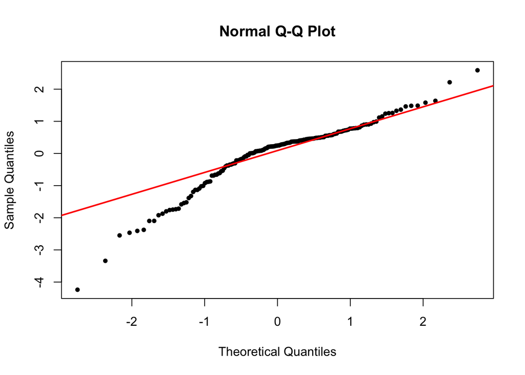

```r
qq_plot(transformed_log_step_from_add)
```

```r
(shapiro_pvalue = get_shapiro_pvalue(transformed_log_step_from_add))
```

```
## [1] 5.313572e-08
```

- LOOCV (multiple linear regression)

```r
calc_loocv_rmse(transformed_log_step_from_add)
```

```
## [1] 1.053327
```

- R^2, RMSE (multiple linear regression)

```r
summary(transformed_log_step_from_add)$r.squared
```

```
## [1] 0.928071
```

```r
summary(transformed_log_step_from_add)$adj.r.squared
```

```
## [1] 0.926739
```

#### Outlier Diagnostics

- Cook’s distance + influence

```r
# cds = cooks.distance(final_model)
# n = length(final_model$fitted.values)
# influential_cd = 4 / n
# influential_points = cds > influential_cd
#
# clean_without_influence = clean_data_subset[!influential_points,]
#
#
# clean_int_log_model = lm(log(total_confirmed) ~ (school_closing + cancel_public_events + stay_at_home_requirements + mobility_parks + mobility_transit_stations)^2, data = clean_without_influence)
# null_log_model = lm(log(total_confirmed) ~ 1, data = clean_without_influence)
# cleaned_log_model = step(
#   null_log_model,
#   scope = total_confirmed ~ (school_closing + cancel_public_events + stay_at_home_requirements + mobility_parks + mobility_transit_stations)^2,
#   direction = "forward", trace = 0)
#
# shapiro.test(cleaned_log_model$residuals)$p.value
# as.vector(bptest(cleaned_log_model)$p.value)
#
# #plot(cleaned_log_model)
```

#### Model Statistics

- LOOCV (multiple linear regression)

```r
calc_loocv_rmse = function(model) {
  sqrt(mean((resid(model) / (1 - hatvalues(model))) ^ 2))
}

calc_loocv_rmse(int_model)
```

```
## [1] 579314
```

- R^2, RMSE (multiple linear regression)

```r
summary(int_model)$r.squared
```

```
## [1] 0.8050407
```

```r
summary(int_model)$adj.r.squared
```

```
## [1] 0.7883666
```

```r
summary(int_model)
```

```
##
## Call:
## lm(formula = total_confirmed ~ (school_closing + cancel_public_events +
##     stay_at_home_requirements + mobility_parks + mobility_transit_stations)^2,
##     data = clean_data_subset)
##
## Residuals:
##      Min       1Q   Median       3Q      Max
## -1376837  -339102     -802   229351  1865571
##
## Coefficients: (2 not defined because of singularities)
##                                                      Estimate Std. Error
## (Intercept)                                           14991.8   312629.1
## school_closing                                        19937.8   742291.7
## cancel_public_events                                 -56436.6   790200.6
## stay_at_home_requirements                           -167358.9   991413.4
## mobility_parks                                         -382.3    19685.4
## mobility_transit_stations                             -9150.0    42740.2
## school_closing:cancel_public_events                   -2403.1   604531.5
## school_closing:stay_at_home_requirements                   NA         NA
## school_closing:mobility_parks                         -1022.1    23695.7
## school_closing:mobility_transit_stations              -1193.4    56489.5
## cancel_public_events:stay_at_home_requirements             NA         NA
## cancel_public_events:mobility_parks                    2886.4    58689.8
## cancel_public_events:mobility_transit_stations         3060.1   159459.9
## stay_at_home_requirements:mobility_parks              24672.2    29375.4
## stay_at_home_requirements:mobility_transit_stations  -10754.1    86909.6
## mobility_parks:mobility_transit_stations                369.8      194.0
##                                                     t value Pr(>|t|)
## (Intercept)                                           0.048   0.9618
## school_closing                                        0.027   0.9786
## cancel_public_events                                 -0.071   0.9432
## stay_at_home_requirements                            -0.169   0.8662
## mobility_parks                                       -0.019   0.9845
## mobility_transit_stations                            -0.214   0.8308
## school_closing:cancel_public_events                  -0.004   0.9968
## school_closing:stay_at_home_requirements                 NA       NA
## school_closing:mobility_parks                        -0.043   0.9656
## school_closing:mobility_transit_stations             -0.021   0.9832
## cancel_public_events:stay_at_home_requirements           NA       NA
## cancel_public_events:mobility_parks                   0.049   0.9608
## cancel_public_events:mobility_transit_stations        0.019   0.9847
## stay_at_home_requirements:mobility_parks              0.840   0.4023
## stay_at_home_requirements:mobility_transit_stations  -0.124   0.9017
## mobility_parks:mobility_transit_stations              1.906   0.0585 .
## ---
## Signif. codes:  0 '***' 0.001 '**' 0.01 '*' 0.05 '.' 0.1 ' ' 1
##
## Residual standard error: 583200 on 152 degrees of freedom
## Multiple R-squared:  0.805,  Adjusted R-squared:  0.7884
## F-statistic: 48.28 on 13 and 152 DF,  p-value: < 2.2e-16
```